# Day 2 - File 04 - Fit and Compare Models

Melinda Higgins

7/29/2020

## Let’s look at some more plots

Let’s look at some more plots of variables we think may be related to predicting the age of the abalones.

Let’s look at age with length and whole weight.

For this let’s try to **GGally** package which makes some cool plots especially matrix scatterplots. It is an extension package for **ggplot2**.

Learn more about **GGally** package at https://cran.r-project.org/web/packages/GGally/index.html.

Also check out the “R Graph Gallery” for ideas, see https://www.r-graph-gallery.com/199-correlation-matrix-with-ggally.html.

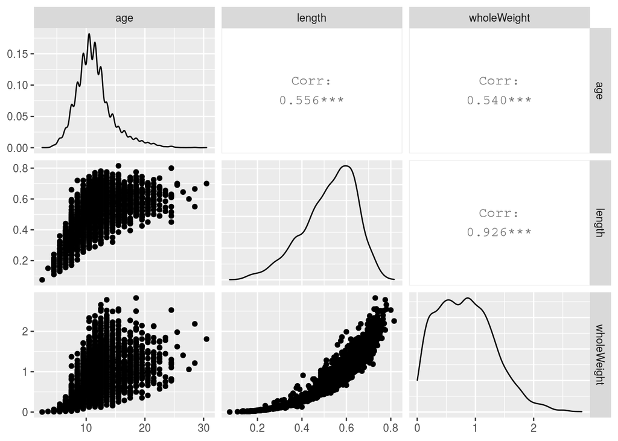

```r
library(GGally)
abaloneMod %>%
  select(age, length, wholeWeight) %>%
  GGally::ggpairs()
```

Color the points by sex - add this aesthetic to the `ggpairs()` function.

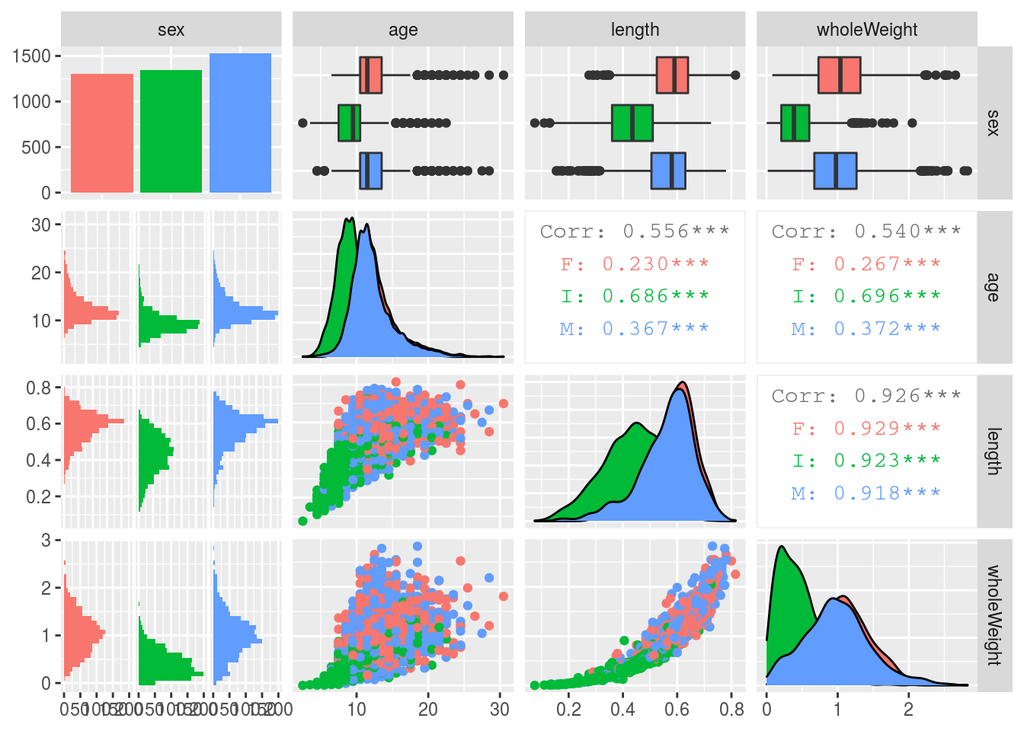

```r
abaloneMod %>%
  select(sex, age, length, wholeWeight) %>%
  GGally::ggpairs(aes(color=sex))
```

## Fit linear models

Since I’d like to compare models, I need to work with a dataset that has no missing data. We can create a dataset with no missing values across all variables as follows.

```r
abaloneMod_complete <- abaloneMod %>%
  filter(complete.cases(abaloneMod))
```

Fit 3 models and save the results and look at the summary of each model.

Model 1 age by length.

```r
lm1 <- lm(age ~ length, data = abaloneMod_complete)
lm1
```

```
##
## Call:
## lm(formula = age ~ length, data = abaloneMod_complete)
##
## Coefficients:
## (Intercept)       length
##        3.61        14.93
```

```r
slm1 <- summary(lm1)
slm1
```

```
##
## Call:
## lm(formula = age ~ length, data = abaloneMod_complete)
##
## Residuals:
##     Min      1Q  Median      3Q     Max
## -5.9664 -1.6970 -0.7424  0.8842 16.6763
##
## Coefficients:
##             Estimate Std. Error t value Pr(>|t|)
## (Intercept)   3.6100     0.1863   19.38   <2e-16 ***
## length       14.9339     0.3463   43.12   <2e-16 ***
## ---
## Signif. codes:  0 '***' 0.001 '**' 0.01 '*' 0.05 '.' 0.1 ' ' 1
##
## Residual standard error: 2.681 on 4167 degrees of freedom
## Multiple R-squared:  0.3086, Adjusted R-squared:  0.3084
## F-statistic:  1860 on 1 and 4167 DF,  p-value: < 2.2e-16
```

```r
slm1[["coefficients"]]
```

```
##              Estimate Std. Error  t value     Pr(>|t|)
## (Intercept)  3.610039  0.1862663 19.38107 3.430299e-80
## length      14.933905  0.3463122 43.12266 0.000000e+00
```

Model 2 age by wholeWeight

```r
lm2 <- lm(age ~ wholeWeight, data = abaloneMod_complete)
slm2 <- summary(lm2)
slm2
```

```
##
## Call:
## lm(formula = age ~ wholeWeight, data = abaloneMod_complete)
##
## Residuals:
##     Min      1Q  Median      3Q     Max
## -6.2621 -1.7529 -0.6926  1.0184 15.7026
##
## Coefficients:
##             Estimate Std. Error t value Pr(>|t|)
## (Intercept)  8.49752    0.08268  102.78   <2e-16 ***
## wholeWeight  3.54628    0.08579   41.34   <2e-16 ***
## ---
## Signif. codes:  0 '***' 0.001 '**' 0.01 '*' 0.05 '.' 0.1 ' ' 1
##
## Residual standard error: 2.715 on 4167 degrees of freedom
## Multiple R-squared:  0.2908, Adjusted R-squared:  0.2907
## F-statistic:  1709 on 1 and 4167 DF,  p-value: < 2.2e-16
```

Model 3 age by length and wholeWeight

```r
lm3 <- lm(age ~ length + wholeWeight,
          data=abaloneMod_complete)
slm3 <- summary(lm3)
slm3
```

```
##
## Call:
## lm(formula = age ~ length + wholeWeight, data = abaloneMod_complete)
##
## Residuals:
##     Min      1Q  Median      3Q     Max
## -5.9966 -1.6784 -0.7441  0.9198 16.3471
##
## Coefficients:
##             Estimate Std. Error t value Pr(>|t|)
## (Intercept)   4.9410     0.3176  15.555  < 2e-16 ***
## length       10.5709     0.9126  11.583  < 2e-16 ***
## wholeWeight   1.1528     0.2232   5.165 2.52e-07 ***
## ---
## Signif. codes:  0 '***' 0.001 '**' 0.01 '*' 0.05 '.' 0.1 ' ' 1
##
## Residual standard error: 2.672 on 4166 degrees of freedom
## Multiple R-squared:  0.313,  Adjusted R-squared:  0.3126
## F-statistic: 948.8 on 2 and 4166 DF,  p-value: < 2.2e-16
```

Compare the full model `lm3` to the reduced models `lm1` or `lm2`.

```r
anova(lm1, lm3) # model with length to full model with both
```

```
## Analysis of Variance Table
##
## Model 1: age ~ length
## Model 2: age ~ length + wholeWeight
##   Res.Df   RSS Df Sum of Sq      F    Pr(>F)
## 1   4167 29944
## 2   4166 29753  1     190.5 26.673 2.522e-07 ***
## ---
## Signif. codes:  0 '***' 0.001 '**' 0.01 '*' 0.05 '.' 0.1 ' ' 1
```

```r
anova(lm2, lm3) # model with WW to full model with both
```

```
## Analysis of Variance Table
##
## Model 1: age ~ wholeWeight
## Model 2: age ~ length + wholeWeight
##   Res.Df   RSS Df Sum of Sq      F    Pr(>F)
## 1   4167 30711
## 2   4166 29753  1    958.22 134.17 < 2.2e-16 ***
## ---
## Signif. codes:  0 '***' 0.001 '**' 0.01 '*' 0.05 '.' 0.1 ' ' 1
```

## Make tables of the coefficients of each model

```r
library(knitr)
knitr::kable(slm1$coefficients,
             caption = "Model 1 Age by Length")
```

Model 1 Age by Length

|  | Estimate | Std. Error | t value | Pr(>\|t\|) |
| --- | --- | --- | --- | --- |
| (Intercept) | 3.610039 | 0.1862663 | 19.38107 | 0 |
| length | 14.933905 | 0.3463122 | 43.12266 | 0 |

```r
knitr::kable(slm2$coefficients,
             caption = "Model 2 Age by Whole Weight")
```

Model 2 Age by Whole Weight

|  | Estimate | Std. Error | t value | Pr(>\|t\|) |
| --- | --- | --- | --- | --- |
| (Intercept) | 8.497525 | 0.0826756 | 102.78152 | 0 |
| wholeWeight | 3.546281 | 0.0857854 | 41.33898 | 0 |

```r
knitr::kable(slm3$coefficients,
             caption = "Model 3 Age by Length and Whole Weight")
```

Model 3 Age by Length and Whole Weight

|  | Estimate | Std. Error | t value | Pr(>\|t\|) |
| --- | --- | --- | --- | --- |
| (Intercept) | 4.941020 | 0.3176445 | 15.555186 | 0e+00 |
| length | 10.570916 | 0.9126122 | 11.583140 | 0e+00 |
| wholeWeight | 1.152848 | 0.2232207 | 5.164609 | 3e-07 |

## Another way to compare models

Use the **stargazer** package to compare models

The default output type is “latex” for making PDF documents. You will need to change this option depending on if you are knitting to HTML or to PDF. This will NOT work for WORD files.

The code chunk option must be set to `results='asis'`.

```r
library(stargazer)

# set for HTML output
stargazer(lm1, lm2, lm3, type="html")
```

|  | *Dependent variable:* |  |  |
| --- | --- | --- | --- |
|  | age |  |  |
|  | (1) | (2) | (3) |
| length | 14.934*** |  | 10.571*** |
|  | (0.346) |  | (0.913) |
| wholeWeight |  | 3.546*** | 1.153*** |
|  |  | (0.086) | (0.223) |
| Constant | 3.610*** | 8.498*** | 4.941*** |
|  | (0.186) | (0.083) | (0.318) |
| Observations | 4,169 | 4,169 | 4,169 |
| R<sup>2</sup> | 0.309 | 0.291 | 0.313 |
| Adjusted R<sup>2</sup> | 0.308 | 0.291 | 0.313 |
| Residual Std. Error | 2.681 (df = 4167) | 2.715 (df = 4167) | 2.672 (df = 4166) |
| F Statistic | 1,859.564*** (df = 1; 4167) | 1,708.911*** (df = 1; 4167) | 948.847*** (df = 2; 4166) |
| *Note:* | p<0.1; p<0.05; p<0.01 |  |  |

```r
# uncomment this if knitting to PDF
# stargazer(lm1, lm2, lm3, type="latex")

# comment all of this out if knitting to WORD
```